# STA 6704 HW 4

Ken Zhao

We will start here with problem 3, the fashion dataset.

First, let’s load the data in.

```r
library(readr)
fashion <- read_csv("fashion-mnist_train.csv")
```

Now, let’s take 2000 samples and split the label and pixel variables. Variables have no need to be scaled on this dataset. We make label a vector to be used in the color labels for qplot (for t-sne) later

```r
#set up data
#sample 2000 from fashion
set.seed(1)
samplerows=sample(1:nrow(fashion),size=2000,
              replace = FALSE)
sample=fashion[samplerows,]
#split label and pixels
label=as.vector(unlist(sample[,1]))
pixel=sample[,2:785]
```

Make and plot the kemans model with number of clusters K=10

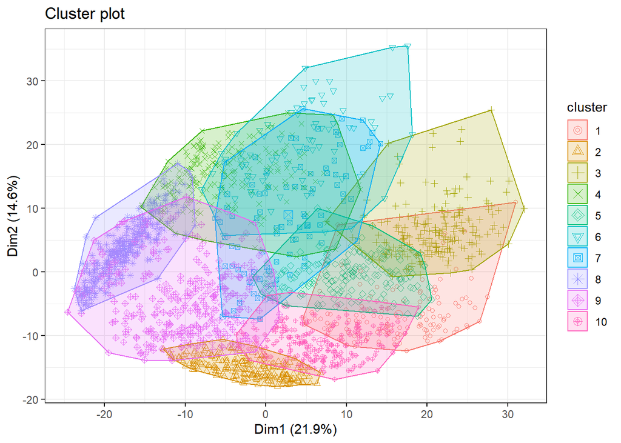

```r
#make kmeans model with K=10
kmeans10 = kmeans(pixel, centers=10)
#plot kmeans with factoextra
library(factoextra)
fviz_cluster(kmeans10, data = pixel,
             geom = "point",
             ellipse.type = "convex",
             ggtheme = theme_bw()
)
```

Create the initial tsne model using 2 dimensions, 30 perplexity, 50 pca dimensions

```r
# make the t-sne model using dimensions=2, perplexity=30 and pca dimensions=50
library(Rtsne)
tsne = Rtsne(pixel, dims=2,
             perplexity=30,
             theta=0.05, initial_dims=50
             )
```

Create a 10 color palette to be used for plotting the tsne model

```r
# get a set of distinctive colors for color-coding the observations
library(RColorBrewer)
# number of unique colors
n = 10
# get 10 distinct colors for plot
qual_col_pals = brewer.pal.info[brewer.pal.info$category == 'qual',]
col_vector = unlist(mapply(brewer.pal, qual_col_pals$maxcolors, rownames(qual_col_pals)))
qual_col_pals$maxcolors
```

```
## [1]  8  8 12  9  8  9  8 12
```

```r
col_vector
```

```
##  [1] "#7FC97F" "#BEAED4" "#FDC086" "#FFFF99" "#386CB0" "#F0027F" "#BF5B17"
##  [8] "#666666" "#1B9E77" "#D95F02" "#7570B3" "#E7298A" "#66A61E" "#E6AB02"
## [15] "#A6761D" "#666666" "#A6CEE3" "#1F78B4" "#B2DF8A" "#33A02C" "#FB9A99"
## [22] "#E31A1C" "#FDBF6F" "#FF7F00" "#CAB2D6" "#6A3D9A" "#FFFF99" "#B15928"
## [29] "#FBB4AE" "#B3CDE3" "#CCEBC5" "#DECBE4" "#FED9A6" "#FFFFCC" "#E5D8BD"
## [36] "#FDDAEC" "#F2F2F2" "#B3E2CD" "#FDCDAC" "#CBD5E8" "#F4CAE4" "#E6F5C9"
## [43] "#FFF2AE" "#F1E2CC" "#CCCCCC" "#E41A1C" "#377EB8" "#4DAF4A" "#984EA3"
## [50] "#FF7F00" "#FFFF33" "#A65628" "#F781BF" "#999999" "#66C2A5" "#FC8D62"
## [57] "#8DA0CB" "#E78AC3" "#A6D854" "#FFD92F" "#E5C494" "#B3B3B3" "#8DD3C7"
## [64] "#FFFFB3" "#BEBADA" "#FB8072" "#80B1D3" "#FDB462" "#B3DE69" "#FCCDE5"
## [71] "#D9D9D9" "#BC80BD" "#CCEBC5" "#FFED6F"
```

Plot the tsne using the above colors and the “label” variable for the dataset and compare it to the plot using the labels kmeans10

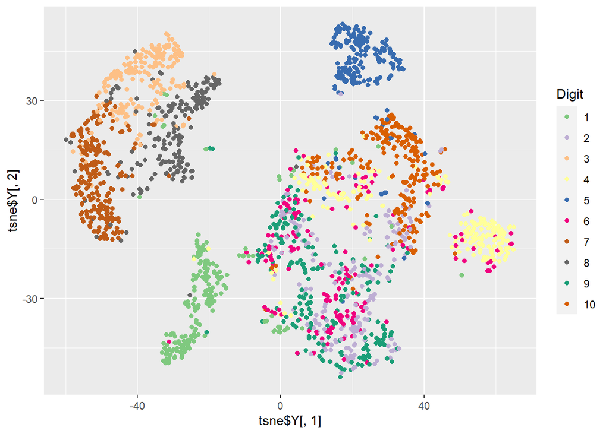

```r
# plot the t-sne embeddings and color-code according to digit
library(ggplot2)
qplot(tsne$Y[,1], tsne$Y[,2], colour=col_vector[label+1]) +
  scale_color_manual(labels = 1:10, values = col_vector[1:10]) +
  labs(colour="Digit")
```

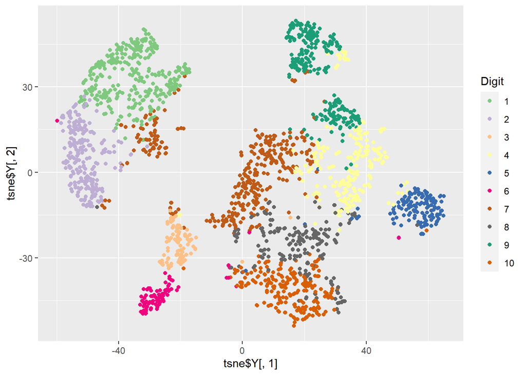

```r
#plot the t-sne embeddings using the kmeans10 from before
qplot(tsne$Y[,1], tsne$Y[,2], colour=col_vector[kmeans10$cluster+1]) +
  scale_color_manual(labels = 1:10, values = col_vector[1:10]) +
  labs(colour="Digit")
```

There are slight variations between the two plots. The data points are obviously in the same spot. Sometimes a cluster in one plot is broken up in the other plot. Sometimes one plot has more mixing between close clusters. Some points are quite far away from the cluster center in one plot compared to the other.

Now, we will do problem 4

Let’s load the data in

```r
#import dataset
library(readr)
parkinsons <- read_csv("parkinsons.csv")
```

Isolate label variable and scale data

```r
#prep data, remove name variable, isolate status(y) variable
parkinsons=parkinsons[,-1]
status=parkinsons[,c("status")]
parkinsons=parkinsons[-c(17)]
#scale data mean 0, variance 1
parkinsons=scale(parkinsons)
```

Create the silhouette function to calculate optimal clusters

```r
#create silhouette function
library(cluster)
# define a function to get the silhouette across different k
silhouette_k_sweep = function(cluster_fn, df, max_k=15){
  sil_scores = c()
  loss_scores = c()
  for(k in 2:max_k){
    # build cluster model
    g_k = cluster_fn(df, k)
    # get the loss for given value of k (requires different code for different cluster_fn)
    if(identical(cluster_fn, kmeans)){
      loss_scores[k-1] = g_k$tot.withinss
    } else if(identical(cluster_fn, pam)){
      loss_scores[k-1] = g_k$objective[1]
    }
    # get the silhoutte scores for all samples and average
    sil_scores[k-1] = mean(silhouette(g_k$cluster, dist(df))[,3])
  }
  # find the optimal k by find the max of the silhoutte scores
  opt_k_sil = which.max(sil_scores) + 1
  return(list(loss_scores=loss_scores, sil_scores=sil_scores, opt_k_sil=opt_k_sil))
}
```

Then, apply and plot the silhouette function for loss and silhouette score.

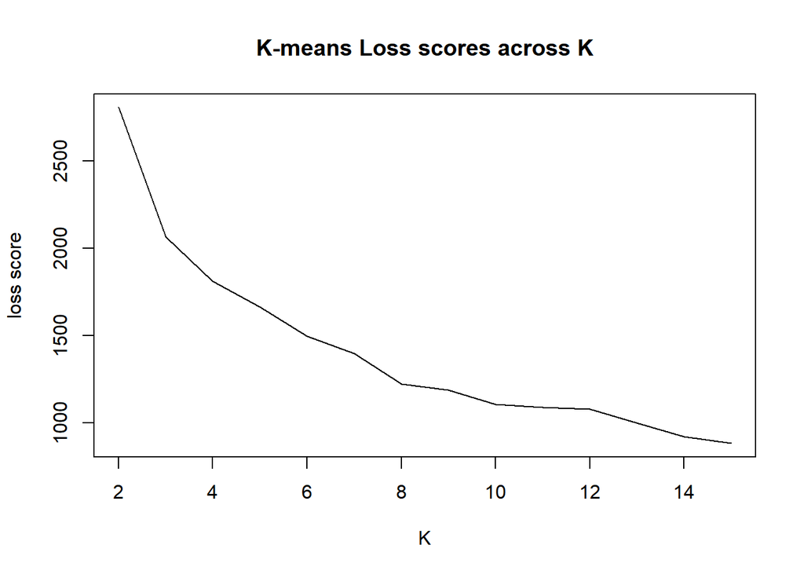

```r
# apply silhoutte function to kmeans function and parkinsons data
sil_sweep_kmeans = silhouette_k_sweep(kmeans, parkinsons)
# plot loss across k (look for bend where loss begin to flatten out)
plot(2:(length(sil_sweep_kmeans$sil_scores)+1), sil_sweep_kmeans$loss_scores,
     main="K-means Loss scores across K", xlab="K", ylab="loss score", type='l')
```

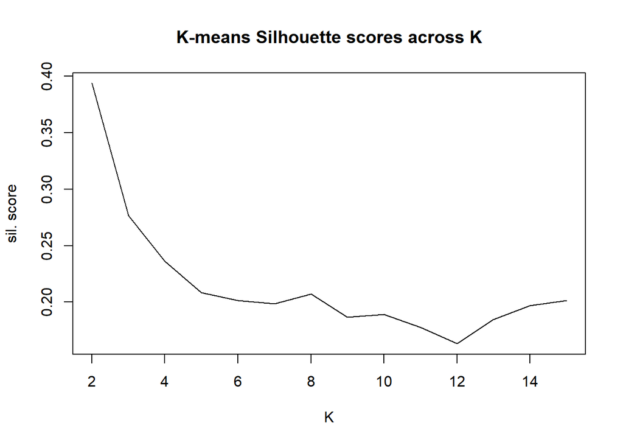

```r
# plot silhouette score across k (larger is better)
plot(2:(length(sil_sweep_kmeans$sil_scores)+1), sil_sweep_kmeans$sil_scores,
     main="K-means Silhouette scores across K", xlab="K", ylab="sil. score", type='l')
```

2 for silhouette and 3 for loss looks pretty good here.

Using those values, let’s run and plot the K means model

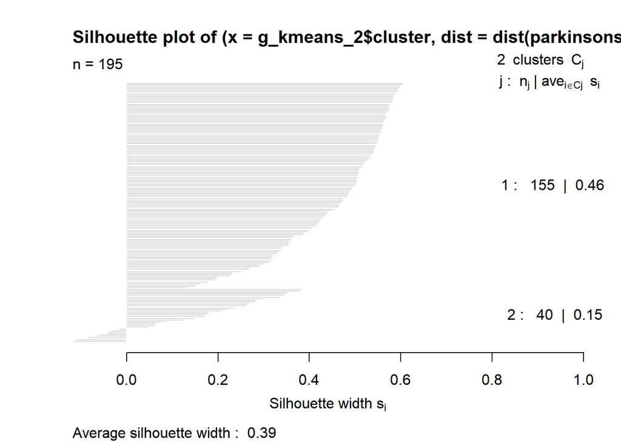

```r
# make kmeans model with optimal k from silhouette
g_kmeans_2 = kmeans(parkinsons, 2)
sil_kmeans_2 = silhouette(g_kmeans_2$cluster, dist(parkinsons))
# plot silhouettes from model
plot(sil_kmeans_2)
```

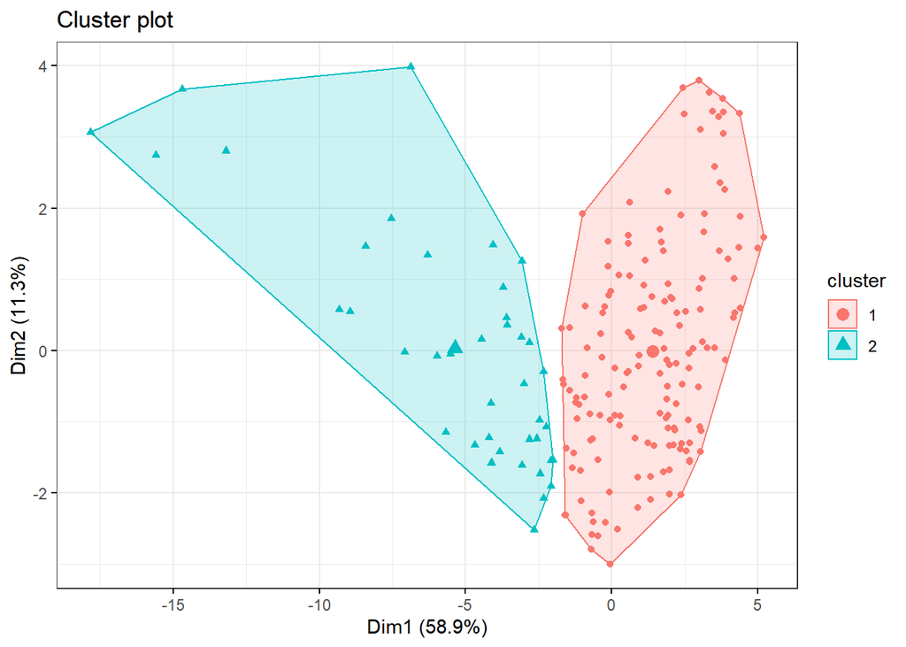

```r
# plot clusters from model
library(factoextra)
fviz_cluster(g_kmeans_2, data = parkinsons,
             geom = "point",
             ellipse.type = "convex",
             ggtheme = theme_bw())
```

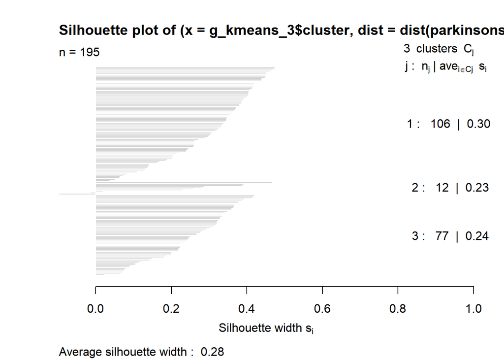

```r
# make kmeans model with optimal k from loss
g_kmeans_3 = kmeans(parkinsons, 3)
sil_kmeans_3 = silhouette(g_kmeans_3$cluster, dist(parkinsons))
# plot silhouettes from model
plot(sil_kmeans_3)
```